# Ridge and Lasso Thresholding: A Didactic Demonstration

Itamar Caspi

(updated: 2025-04-20)

Abstract

This short tutorial illustrates, in the simplest possible setting, the similarities and differences between ordinary least‑squares (OLS), ridge, and lasso estimators. With an orthonormal design matrix (the identity), analytic solutions exist: ridge uniformly shrinks coefficients toward zero while lasso applies a soft–thresholding rule that can set small coefficients exactly to zero. Using simulated data we fit all three models, visualise their estimates, and discuss the intuition behind each penalisation scheme.

# 1. Background

Shrinkage and selection procedures are essential when the analyst wishes to prevent over‑fitting or perform variable selection.  
Two classics are:

- **Ridge regression** (ℓ² penalty) — continuous shrinkage, never sets coefficients exactly to zero.
- **Lasso** (ℓ¹ penalty) — soft‑thresholding that can zero out small coefficients, thereby performing implicit model selection.

In an *orthonormal* design matrix $X'X = I$, their solutions simplify to scalar operations on the OLS estimates, which makes the mechanics crystal‑clear.

# 2. Data‑generating mechanism

For didactic clarity we simulate the most elementary scenario: the design matrix is the identity and the response is a linear trend.

```r
# response: a deterministic linear trend
y      <- seq(-0.5, 0.5, 0.1)
n      <- length(y)

# design matrix: identity (orthonormal)
X      <- diag(n)

# penalty magnitude
lambda <- 0.1
```

#### 2.1. Why is $\hat\beta^{\text{OLS}} = y$ when $X = I$?

The ordinary least‑squares estimator solves
$$\displaystyle \hat\beta^{\text{OLS}} =
\arg\min_{\beta} \; \tfrac{1}{2}\lVert y - X\beta
\rVert_2^2$$
.

If $X = I_n$ (and there is no intercept), the objective collapses to $\tfrac{1}{2}\lVert y - \beta \rVert_2^2$, whose unique minimiser is $\beta = y$.

Equivalently, the normal equations give
$$X'X\,\hat\beta^{\text{OLS}} = X'y
\;\;\Rightarrow\;\; I_n \hat\beta^{\text{OLS}} = y \;\;\Rightarrow\;\;
\hat\beta^{\text{OLS}} = y.$$

Thus any departure of the ridge or lasso estimates from $y$ is attributable solely to the penalties.

# 3. Estimators

## 3.1. Ordinary least squares

```r
ols <- lm(y ~ X - 1)   # -1 removes the intercept term
b_ols <- coef(ols)
```

Because $X = I$, $\hat\beta^{\text{OLS}} = y$.

## 3.2. Ridge regression

```r
ridge <- glmnet(
  x = X,
  y = y,
  alpha = 0,           # 0 = ridge
  standardize = TRUE, # already orthonormal
  intercept = FALSE
)
b_ridge <- coef(ridge, s = lambda)[2:(n+1), 1]
```

With an orthonormal design the closed‑form is

## 3.3. Lasso

```r
lasso <- glmnet(
  x = X,
  y = y,
  alpha = 1,           # 1 = lasso
  standardize = TRUE,
  intercept = FALSE
)
b_lasso <- coef(lasso, s = lambda)[2:(n+1), 1]
```

The lasso solution applies the *soft‑thresholding* operator

# 4. Visual comparison

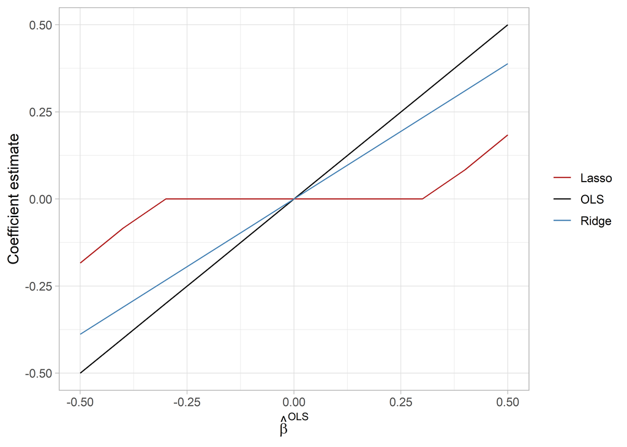

```r
bs <- tibble(
  beta_OLS   = b_ols,
  beta_lasso = b_lasso,
  beta_ridge = b_ridge
)

bs %>%
  ggplot(aes(x = beta_OLS)) +
  geom_line(aes(y = beta_OLS,   colour = "OLS")) +
  geom_line(aes(y = beta_lasso, colour = "Lasso")) +
  geom_line(aes(y = beta_ridge, colour = "Ridge")) +
  scale_colour_manual(NULL, values = c("OLS" = "black", "Lasso" = "firebrick", "Ridge" = "steelblue")) +
  labs(
    x = expression(hat(beta)^{OLS}),
    y = "Coefficient estimate"
  ) +
  theme_light(base_size = 12)
```

# 5. Take‑aways

- **Uniform vs. selective shrinkage**: Ridge treats all coefficients equally, whereas lasso discriminates based on magnitude.
- **Model selection**: Lasso can yield a sparse model *without an explicit selection step*.
- **Orthonormal design as a microscope**: Using $X = I$ isolates the penalty’s action, free from multicollinearity or scaling issues.